# final_project_AA

lucy

December 5, 2018

Load packages

```r
### Load helper packages ###
loadlibs = function(libs) {
  for(lib in libs) {
    class(lib)
    if(!do.call(require,as.list(lib))) {install.packages(lib)}
    do.call(require,as.list(lib))
  }
}
libs = c("tidyr","magrittr","purrr","dplyr","stringr","readr","data.table", "lubridate")
loadlibs(libs)
```

Load data 2007-2008,2005-2006 from RNHANES

```r
library(RNHANES)
```

```r
#Df_total <- nhanes_data_files() # gives you the list of files.

#demographic, gender, age, race, total number of people in the family and household
demo07 <- nhanes_load_data("DEMO_E", year = "2007-2008")%>%data.frame()%>%as_tibble()%>%select(SEQN, RIAGENDR, DMDHRAGE,RIDRETH1, DMDFMSIZ,DMDHHSIZ)
demo06 <- nhanes_load_data("DEMO_D", year = "2005-2006")%>%data.frame()%>%as_tibble()%>%select(SEQN, RIAGENDR, DMDHRAGE,RIDRETH1, DMDFMSIZ,DMDHHSIZ)
#Ophthalmology, Y(retinopothy), retinal microaneurysms, retinal hard exudate
reti07 = nhanes_load_data("OPXRET_E", year = "2007-2008")%>%data.frame()%>%as_tibble()%>%select(SEQN,OPDDARMA,OPDSARMA,OPDUHEM,OPDUHE,OPDUSE)
reti06 = nhanes_load_data("OPXRET_D", year = "2005-2006")%>%data.frame()%>%as_tibble()%>%select(SEQN,OPDDARMA,OPDSARMA,OPDUHEM,OPDUHE,OPDUSE)
#vision,had surgery for cataract before, visual acuity of left eyes and right eyes, wearing glasses or not
vision_07 <- nhanes_load_data("VIX_E", year = "2007-2008")%>%data.frame()%>%as_tibble%>%select(SEQN,VIQ200,VIDLOVA, VIDROVA, VIQ150)
vision_06 <- nhanes_load_data("VIX_D", year = "2005-2006")%>%data.frame()%>%as_tibble%>%select(SEQN,VIQ200,VIDLOVA, VIDROVA,VIQ150)
#bmx, BOdy mass index, weight
bmx_07 <- nhanes_load_data("BMX_E", year = "2007-2008")%>%data.frame()%>%as_tibble%>%select(SEQN,BMXBMI, BMXWT)
bmx_06 <- nhanes_load_data("BMX_D", year = "2005-2006")%>%data.frame()%>%as_tibble%>%select(SEQN,BMXBMI, BMXWT)
#glu, fasting glucose
glu_07 <- nhanes_load_data("GLU_E", year = "2007-2008")%>%data.frame()%>%as_tibble%>%select(SEQN,LBXGLU)
glu_06 <- nhanes_load_data("GLU_D", year = "2005-2006")%>%data.frame()%>%as_tibble%>%select(SEQN,LBXGLU)
```

Join data, Split data into train and test

```r
#Join the data in 2007
patient07 = reti07%>%left_join(demo07,by = "SEQN")%>%left_join(vision_07,by = "SEQN")%>%left_join(bmx_07,by = "SEQN")%>%left_join(glu_07,by = "SEQN")

#create Y column
patient07=patient07%>%mutate(RETI = ifelse(OPDDARMA==1|OPDSARMA==1,1,0))%>%select(-OPDDARMA,-OPDSARMA,-SEQN)
#join data in 2006
patient06 = reti06%>%left_join(demo06,by = "SEQN")%>%left_join(vision_06,by = "SEQN")%>%left_join(bmx_06,by = "SEQN")%>%left_join(glu_06,by = "SEQN")

patient06=patient06%>%mutate(RETI = ifelse(OPDDARMA==1|OPDSARMA==1,1,0))%>%select(-OPDDARMA,-OPDSARMA,-SEQN)

#combine all the data
patient = patient07%>%rbind(patient06)

patient=patient%>%filter(!is.na(RETI))%>%filter(DMDHRAGE>=40)


#randominze the data and split
set.seed(504)
patient=patient[sample(1:nrow(patient)),]

summary(patient)
```

```
##     OPDUHEM            OPDUHE            OPDUSE           RIAGENDR
##  Min.   :0.00000   Min.   :0.00000   Min.   :0.00000   Min.   :1.000
##  1st Qu.:0.00000   1st Qu.:0.00000   1st Qu.:0.00000   1st Qu.:1.000
##  Median :0.00000   Median :0.00000   Median :0.00000   Median :2.000
##  Mean   :0.03828   Mean   :0.05338   Mean   :0.05726   Mean   :1.503
##  3rd Qu.:0.00000   3rd Qu.:0.00000   3rd Qu.:0.00000   3rd Qu.:2.000
##  Max.   :1.00000   Max.   :2.00000   Max.   :2.00000   Max.   :2.000
##  NA's   :215
##     DMDHRAGE        RIDRETH1        DMDFMSIZ        DMDHHSIZ
##  Min.   :40.00   Min.   :1.000   Min.   :1.000   Min.   :1.000
##  1st Qu.:49.00   1st Qu.:3.000   1st Qu.:2.000   1st Qu.:2.000
##  Median :60.00   Median :3.000   Median :2.000   Median :2.000
##  Mean   :59.86   Mean   :2.909   Mean   :2.578   Mean   :2.677
##  3rd Qu.:70.00   3rd Qu.:3.000   3rd Qu.:3.000   3rd Qu.:3.000
##  Max.   :85.00   Max.   :5.000   Max.   :7.000   Max.   :7.000
##
##      VIQ200         VIDLOVA          VIDROVA           VIQ150
##  Min.   :1.000   Min.   : 25.00   Min.   : 25.00   Min.   :1.000
##  1st Qu.:2.000   1st Qu.: 25.00   1st Qu.: 25.00   1st Qu.:1.000
##  Median :2.000   Median : 25.00   Median : 25.00   Median :1.000
##  Mean   :1.887   Mean   : 45.09   Mean   : 45.05   Mean   :1.138
##  3rd Qu.:2.000   3rd Qu.: 30.00   3rd Qu.: 30.00   3rd Qu.:1.000
##  Max.   :9.000   Max.   :666.00   Max.   :666.00   Max.   :9.000
##  NA's   :2       NA's   :3506     NA's   :3535     NA's   :1350
##      BMXBMI           BMXWT            LBXGLU           RETI
##  Min.   : 13.36   Min.   : 35.90   Min.   : 45.0   Min.   :0.0000
##  1st Qu.: 24.91   1st Qu.: 68.10   1st Qu.: 96.0   1st Qu.:0.0000
##  Median : 28.35   Median : 79.80   Median :103.0   Median :0.0000
##  Mean   : 29.25   Mean   : 82.23   Mean   :113.8   Mean   :0.1289
##  3rd Qu.: 32.41   3rd Qu.: 92.90   3rd Qu.:115.0   3rd Qu.:0.0000
##  Max.   :130.21   Max.   :371.00   Max.   :470.0   Max.   :1.0000
##  NA's   :36       NA's   :31       NA's   :2725
```

```r
#70% as train, 30% as test
p_train = patient[1:as.integer(nrow(patient)*0.7),]
p_test = patient[-(1:as.integer(nrow(patient)*0.7)),]
```

Impute training data and include all imputed data as training data Impute testing data and include all imputed data as testing data

```r
#imputation
#I use mutiple imputation to impute the missing data. Because in this case, the missing data is MCAR so that can use MICE to impute.
#install.packages("mice")
library(mice)
ptrain = mice(p_train %>%
              select(-RETI) %>%
              mutate_if(is.character, as.factor),m=10,maxit = 5)
# Get all imputed data set
alldata = function(x,y){
  imputed_p = NULL
  for (i in (1:5)){
    imp = complete(x,i) %>% as_tibble()
    names(imp) = lapply(names(imp), paste0, "_imputed")
    # Rename those columns in case you want to column append
    miss = apply(y,FUN = (function(x) any(is.na(x))),MARGIN = 2)
    miss = miss[-which(names(miss)=="RETI")]
    imp = imp[,paste0(names(miss %>% t() %>% data.frame()),"_imputed")]
    imputed = data.frame(RETI = y$RETI) %>% bind_cols(imp) %>% as_tibble()
    imputed_p = imputed_p%>%rbind(imputed)
  }
  imputed_p

}

imputed_ptrain = alldata(ptrain,p_train)


#get test imputed data
ptest = mice(p_test %>%
              select(-RETI) %>%
              mutate_if(is.character, as.factor),m=10,maxit = 5)
imputed_ptest = alldata(ptest,p_test)
```

Without ophthalmology variables: this analysis is intended for the situation where you know very little about the person (e.g. demographics only), and you want to know what effect measuring fasting blood glucose will have on risk of retinopathy. Preparation: Data that has glucose or not

```r
p_train_noo_noglu = imputed_ptrain%>%select(-c(OPDUHEM_imputed,OPDUHE_imputed,OPDUSE_imputed,LBXGLU_imputed))
p_train_noo_glu = imputed_ptrain%>%select(-c(OPDUHEM_imputed,OPDUHE_imputed,OPDUSE_imputed))


p_test_noo_noglu = imputed_ptest%>%select(-c(OPDUHEM_imputed,OPDUHE_imputed,OPDUSE_imputed,LBXGLU_imputed))
p_test_noo_glu = imputed_ptest%>%select(-c(OPDUHEM_imputed,OPDUHE_imputed,OPDUSE_imputed))
```

trian the model

```r
#logistic regression
ptrain_lr_noo_noglu = glm(RETI == 1 ~ ., data =p_train_noo_noglu ,  family = binomial("logit"))

ptrain_lr_noo_glu = glm(RETI == 1 ~ ., data =p_train_noo_glu ,  family = binomial("logit"))

summary(ptrain_lr_noo_noglu)
```

```
##
## Call:
## glm(formula = RETI == 1 ~ ., family = binomial("logit"), data = p_train_noo_noglu)
##
## Deviance Residuals:
##     Min       1Q   Median       3Q      Max
## -1.4178  -0.5595  -0.4674  -0.3826   2.6277
##
## Coefficients:
##                    Estimate Std. Error z value Pr(>|z|)
## (Intercept)      -3.7220266  0.2880186 -12.923  < 2e-16 ***
## RIAGENDR_imputed -0.5550950  0.0633396  -8.764  < 2e-16 ***
## DMDHRAGE_imputed  0.0258173  0.0021611  11.947  < 2e-16 ***
## RIDRETH1_imputed  0.0966454  0.0239679   4.032 5.52e-05 ***
## DMDFMSIZ_imputed -0.0870087  0.0399410  -2.178 0.029374 *
## DMDHHSIZ_imputed  0.1948396  0.0398789   4.886 1.03e-06 ***
## VIQ200_imputed   -0.4347163  0.0632508  -6.873 6.29e-12 ***
## VIDLOVA_imputed   0.0014152  0.0002112   6.701 2.07e-11 ***
## VIDROVA_imputed   0.0007171  0.0002050   3.498 0.000469 ***
## VIQ150_imputed    0.0210418  0.0592151   0.355 0.722332
## BMXBMI_imputed    0.0990331  0.0090969  10.886  < 2e-16 ***
## BMXWT_imputed    -0.0213294  0.0031166  -6.844 7.71e-12 ***
## ---
## Signif. codes:  0 '***' 0.001 '**' 0.01 '*' 0.05 '.' 0.1 ' ' 1
##
## (Dispersion parameter for binomial family taken to be 1)
##
##     Null deviance: 14032  on 18029  degrees of freedom
## Residual deviance: 13426  on 18018  degrees of freedom
## AIC: 13450
##
## Number of Fisher Scoring iterations: 5
```

```r
summary(ptrain_lr_noo_glu)
```

```
##
## Call:
## glm(formula = RETI == 1 ~ ., family = binomial("logit"), data = p_train_noo_glu)
##
## Deviance Residuals:
##     Min       1Q   Median       3Q      Max
## -2.0746  -0.5329  -0.4366  -0.3589   2.6854
##
## Coefficients:
##                    Estimate Std. Error z value Pr(>|z|)
## (Intercept)      -4.3841868  0.2969955 -14.762  < 2e-16 ***
## RIAGENDR_imputed -0.4607557  0.0651252  -7.075 1.50e-12 ***
## DMDHRAGE_imputed  0.0218715  0.0022238   9.835  < 2e-16 ***
## RIDRETH1_imputed  0.1147912  0.0244049   4.704 2.56e-06 ***
## DMDFMSIZ_imputed -0.1088614  0.0406428  -2.678  0.00740 **
## DMDHHSIZ_imputed  0.2076122  0.0405810   5.116 3.12e-07 ***
## VIQ200_imputed   -0.4657492  0.0647475  -7.193 6.32e-13 ***
## VIDLOVA_imputed   0.0014020  0.0002166   6.473 9.59e-11 ***
## VIDROVA_imputed   0.0006298  0.0002115   2.977  0.00291 **
## VIQ150_imputed   -0.0362393  0.0621706  -0.583  0.55996
## BMXBMI_imputed    0.0797633  0.0094008   8.485  < 2e-16 ***
## BMXWT_imputed    -0.0195096  0.0032082  -6.081 1.19e-09 ***
## LBXGLU_imputed    0.0106392  0.0004546  23.403  < 2e-16 ***
## ---
## Signif. codes:  0 '***' 0.001 '**' 0.01 '*' 0.05 '.' 0.1 ' ' 1
##
## (Dispersion parameter for binomial family taken to be 1)
##
##     Null deviance: 14032  on 18029  degrees of freedom
## Residual deviance: 12860  on 18017  degrees of freedom
## AIC: 12886
##
## Number of Fisher Scoring iterations: 5
```

Test model and See the comparation results of -ophthalmology,(+-glucose)

```r
library(pROC)
```

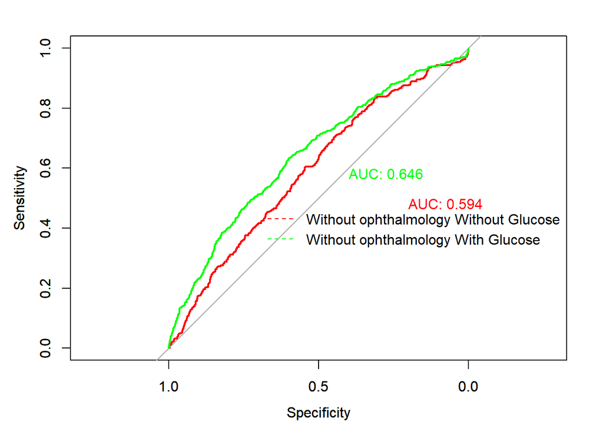

```r
#par(mar=c(5,4,5,3), xpd=TRUE)
#lr roc
result_lr_noo_noglu = p_test_noo_noglu%>%select(RETI)%>%bind_cols(pred = predict(ptrain_lr_noo_noglu, p_test_noo_noglu, type  = "response"))%>%na.omit()
result_lr_noo_glu = p_test_noo_glu%>%select(RETI)%>%bind_cols(pred = predict(ptrain_lr_noo_glu,p_test_noo_glu, type  = "response"))%>%na.omit()


lrroc_noo_noglu <- roc(result_lr_noo_noglu$RETI,result_lr_noo_noglu$pred)
plot(lrroc_noo_noglu, print.auc=TRUE,col = "red",print.auc.x = 0.2,print.auc.y = 0.5)

par(new=TRUE)

lrroc_noo_glu <- roc(result_lr_noo_glu$RETI,result_lr_noo_glu$pred)
plot(lrroc_noo_glu, print.auc=TRUE,col = "green",print.auc.x = 0.4,print.auc.y = 0.6)


#imputed_ptest$RETI = as.factor(imputed_ptest$RETI)
#rf roc
#result_rf = imputed_ptest%>%select(RETI)%>%bind_cols(pred = predict(pforest, imputed_ptest, type = "prob"))%>%na.omit()

#rfroc <- roc(result_rf$RETI,as.numeric(result_rf$pred))
#plot(rfroc, print.auc=TRUE,col = "green",add=TRUE,print.auc.x = 0.4,print.auc.y = 0.4)


legend("topright", c("Without ophthalmology Without Glucose", "Without ophthalmology With Glucose"), lty=2,
    col = c("red", "green"), bty="n", inset=c(0,0.5))
```

```r
#without glucose
glm.pred1 = rep("0",7730)
glm.pred1[result_lr_noo_noglu$pred>.5] = "1"
table(glm.pred1,p_test_noo_noglu$RETI)
```

```
##
## glm.pred1    0    1
##         0 6768  949
##         1   12    1
```

```r
#with glucose
glm.pred2 = rep("0",7730)
glm.pred2[result_lr_noo_glu$pred>.5] = "1"
table(glm.pred2,p_test_noo_glu$RETI)
```

```
##
## glm.pred2    0    1
##         0 6723  911
##         1   57   39
```

```r
p_train_o_noglu = imputed_ptrain%>%select(-LBXGLU_imputed)
p_train_o_glu = imputed_ptrain


p_test_o_noglu = imputed_ptest%>%select(-LBXGLU_imputed)
p_test_o_glu = imputed_ptest
```

trian the model

```r
#logistic regression
ptrain_lr_o_noglu = glm(RETI == 1 ~ ., data =p_train_o_noglu ,  family = binomial("logit"))

ptrain_lr_o_glu = glm(RETI == 1 ~ ., data =p_train_o_glu ,  family = binomial("logit"))

summary(ptrain_lr_o_noglu)
```

```
##
## Call:
## glm(formula = RETI == 1 ~ ., family = binomial("logit"), data = p_train_o_noglu)
##
## Deviance Residuals:
##     Min       1Q   Median       3Q      Max
## -4.0285  -0.4084  -0.3531  -0.2943   2.7589
##
## Coefficients:
##                    Estimate Std. Error z value Pr(>|z|)
## (Intercept)      -3.695e+00  3.670e-01 -10.068  < 2e-16 ***
## OPDUHEM_imputed   3.796e+00  1.048e-01  36.206  < 2e-16 ***
## OPDUHE_imputed    1.794e+00  9.855e-02  18.209  < 2e-16 ***
## OPDUSE_imputed    2.436e+00  1.091e-01  22.316  < 2e-16 ***
## RIAGENDR_imputed -6.003e-01  7.990e-02  -7.513 5.79e-14 ***
## DMDHRAGE_imputed  1.513e-02  2.727e-03   5.550 2.86e-08 ***
## RIDRETH1_imputed  1.232e-01  3.003e-02   4.102 4.09e-05 ***
## DMDFMSIZ_imputed -1.579e-02  5.101e-02  -0.310  0.75694
## DMDHHSIZ_imputed  1.381e-01  5.104e-02   2.705  0.00683 **
## VIQ200_imputed   -3.814e-01  8.371e-02  -4.556 5.21e-06 ***
## VIDLOVA_imputed   4.464e-04  3.219e-04   1.387  0.16548
## VIDROVA_imputed   3.754e-05  2.855e-04   0.131  0.89538
## VIQ150_imputed    8.744e-02  7.236e-02   1.208  0.22687
## BMXBMI_imputed    8.738e-02  1.142e-02   7.652 1.98e-14 ***
## BMXWT_imputed    -1.945e-02  3.925e-03  -4.955 7.23e-07 ***
## ---
## Signif. codes:  0 '***' 0.001 '**' 0.01 '*' 0.05 '.' 0.1 ' ' 1
##
## (Dispersion parameter for binomial family taken to be 1)
##
##     Null deviance: 14032.0  on 18029  degrees of freedom
## Residual deviance:  9296.8  on 18015  degrees of freedom
## AIC: 9326.8
##
## Number of Fisher Scoring iterations: 6
```

```r
summary(ptrain_lr_o_glu)
```

```
##
## Call:
## glm(formula = RETI == 1 ~ ., family = binomial("logit"), data = p_train_o_glu)
##
## Deviance Residuals:
##     Min       1Q   Median       3Q      Max
## -3.9727  -0.4068  -0.3490  -0.2918   2.7625
##
## Coefficients:
##                    Estimate Std. Error z value Pr(>|z|)
## (Intercept)      -3.927e+00  3.702e-01 -10.609  < 2e-16 ***
## OPDUHEM_imputed   3.770e+00  1.050e-01  35.897  < 2e-16 ***
## OPDUHE_imputed    1.752e+00  9.874e-02  17.745  < 2e-16 ***
## OPDUSE_imputed    2.379e+00  1.101e-01  21.602  < 2e-16 ***
## RIAGENDR_imputed -5.701e-01  8.031e-02  -7.098 1.26e-12 ***
## DMDHRAGE_imputed  1.389e-02  2.743e-03   5.065 4.08e-07 ***
## RIDRETH1_imputed  1.311e-01  3.010e-02   4.355 1.33e-05 ***
## DMDFMSIZ_imputed -1.846e-02  5.077e-02  -0.364  0.71610
## DMDHHSIZ_imputed  1.384e-01  5.078e-02   2.724  0.00644 **
## VIQ200_imputed   -3.899e-01  8.366e-02  -4.661 3.15e-06 ***
## VIDLOVA_imputed   4.491e-04  3.225e-04   1.393  0.16369
## VIDROVA_imputed   1.709e-05  2.865e-04   0.060  0.95244
## VIQ150_imputed    7.639e-02  7.275e-02   1.050  0.29374
## BMXBMI_imputed    8.219e-02  1.149e-02   7.157 8.28e-13 ***
## BMXWT_imputed    -1.894e-02  3.929e-03  -4.821 1.43e-06 ***
## LBXGLU_imputed    3.418e-03  6.893e-04   4.960 7.07e-07 ***
## ---
## Signif. codes:  0 '***' 0.001 '**' 0.01 '*' 0.05 '.' 0.1 ' ' 1
##
## (Dispersion parameter for binomial family taken to be 1)
##
##     Null deviance: 14032.0  on 18029  degrees of freedom
## Residual deviance:  9274.4  on 18014  degrees of freedom
## AIC: 9306.4
##
## Number of Fisher Scoring iterations: 6
```

Test model and See the comparation results of +ophthalmology,(+-glucose)

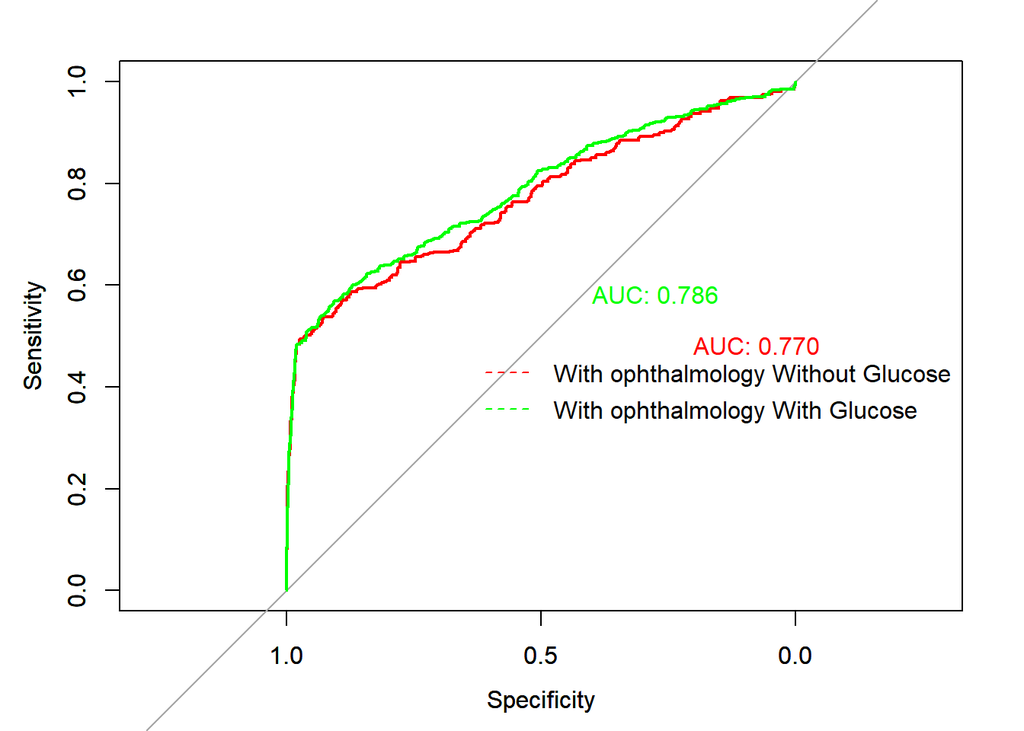

```r
library(pROC)

par(mar=c(5,4,5,3), xpd=TRUE)
#lr roc
result_lr_o_noglu = p_test_o_noglu%>%select(RETI)%>%bind_cols(pred = predict(ptrain_lr_o_noglu, p_test_o_noglu, type  = "response"))%>%na.omit()
result_lr_o_glu = p_test_o_glu%>%select(RETI)%>%bind_cols(pred = predict(ptrain_lr_o_glu,p_test_o_glu, type  = "response"))%>%na.omit()


lrroc_o_noglu <- roc(result_lr_o_noglu$RETI,result_lr_o_noglu$pred)
plot(lrroc_o_noglu, print.auc=TRUE,col = "red",print.auc.x = 0.2,print.auc.y = 0.5)

par(new=TRUE)

lrroc_o_glu <- roc(result_lr_o_glu$RETI,result_lr_o_glu$pred)
plot(lrroc_o_glu, print.auc=TRUE,col = "green",print.auc.x = 0.4,print.auc.y = 0.6)


legend("topright", c("With ophthalmology Without Glucose", "With ophthalmology With Glucose"), lty=2,
    col = c("red", "green"), bty="n", inset=c(0,0.5))
```

```r
#without glucose
glm.pred3 = rep("0",7730)
glm.pred3[result_lr_o_noglu$pred>.5] = "1"
table(glm.pred3,p_test_o_noglu$RETI)
```

```
##
## glm.pred3    0    1
##         0 6664  527
##         1  116  423
```

```r
#with glucose
glm.pred4 = rep("0",7730)
glm.pred4[result_lr_o_glu$pred>.5] = "1"
table(glm.pred4,p_test_o_glu$RETI)
```

```
##
## glm.pred4    0    1
##         0 6662  520
##         1  118  430
```